# Introduction to budgetr

Derek Damron

2016-10-23

## What is budgetr?

*budgetr*, as you might have guessed, is an R package that helps you easily create budgets.

This introductory vignette provides a brief description of the functions provided by *budgetr* along with some simple examples on how to construct your budget. Please refer to the function documentation for more technical information on each of these functions.

## Building a Budget

*budgetr* makes it easy to extend your recurring monthly cash flow out over time. To do this, *budgetr* uses three primary abstractions:

1. **Items**: The individual pieces that make up your budget.
   - E.g. pay checks, rent, groceries
2. **Schedules**: A collection of **items** that detail your cash flow.
3. **Budgets**: A **schedule** that has been applied over a set period of time with a certain initial amount.

## A Quick Example

Your first step in budgeting is to create the items themselves, which you can do with the `create_item` function:

```r
# Create a paycheck item
paycheck <- create_item( name = "Paycheck"
                       , amount = 1000
                       , day = "2017-01-01"
                       , recurring = "monthly"
                       )
# Create a rent item
rent <- create_item( name = "Rent"
                   , amount = -500
                   , day = "2017-01-05"
                   , recurring = "monthly"
                   )
# Create an internet item
internet <- create_item( name = "Internet"
                       , amount = -100
                       , day = "2017-01-05"
                       , recurring = "monthly"
                       )
```

Next you need to create a schedule out of these items, which you can do with the `create_schedule` function:

```r
your_schedule <- create_schedule(paycheck, rent, internet)
```

Lastly (but not leastly!) you need to create your budget, which you can do with the `create_budget` function:

```r
your_budget <- create_budget(your_schedule, start="2017-01-01", initial=1000)
```

Let’s see what it looks like!

```r
your_budget
```

```
## budget (budgetr)
##        date           name amount balance
##  2017-01-01 Initial Amount   1000    1000
##  2017-01-01       Paycheck   1000    2000
##  2017-01-05           Rent   -500    1500
##  2017-01-05       Internet   -100    1400
##  2017-02-01       Paycheck   1000    2400
##  2017-02-05           Rent   -500    1900
##  2017-02-05       Internet   -100    1800
##  2017-03-01       Paycheck   1000    2800
##  2017-03-05           Rent   -500    2300
##  2017-03-05       Internet   -100    2200
##  2017-04-01       Paycheck   1000    3200
```

Looks like you’re netting $400 a month, but let’s plot it out to get a visual!

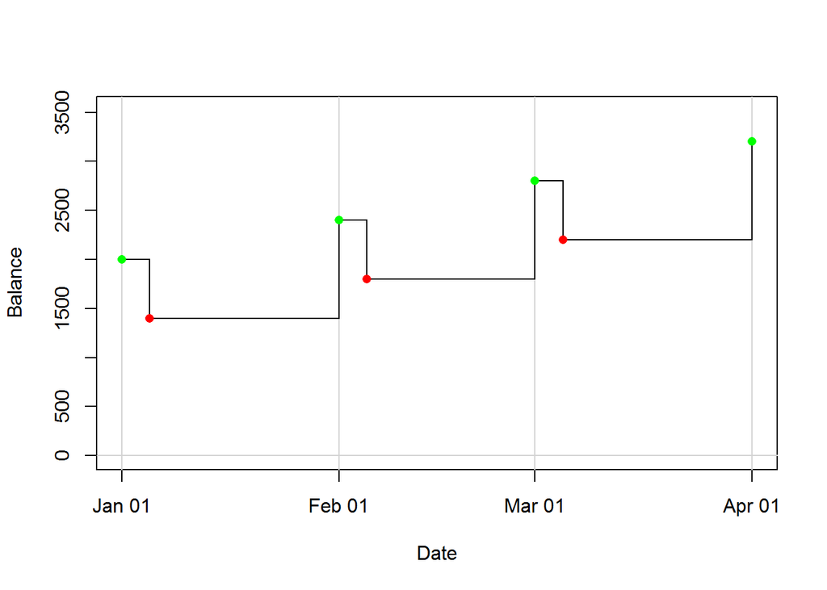

```r
plot(your_budget)
```

## A Realistic Example

In reality we have a lot more than three items in our budget. Let’s say that we *actually* have the following things in our budget for the next few months:

- Paychecks on the 1st and 15th of each month
- Groceries every week
- Rent on the 5th day of each month
- Internet on the 15th of each month
- Student loan on the 23rd of each month
- Car payment on the 25th of each month

First we need to create those items:

```r
# Paycheck items
paycheck1 <- create_item( name = "Paycheck"
                        , amount = 1000
                        , day = "2017-01-01"
                        , recurring = "monthly"
                        )
paycheck15 <- create_item( name = "Paycheck"
                         , amount = 1000
                         , day = "2017-01-15"
                         , recurring = "monthly"
                         )
# Grocery items
groceries <- create_item( name = "Groceries"
                        , amount = -100
                        , day = "2017-01-01"
                        , recurring = "weekly"
                        )
# Rent item
rent <- create_item( name = "Rent"
                   , amount = -500
                   , day = "2017-01-05"
                   , recurring = "monthly"
                   )
# Internet item
internet <- create_item( name = "Internet"
                       , amount = -100
                       , day = "2017-01-15"
                       , recurring = "monthly"
                       )
# Student loan item
student_loan <- create_item( name = "Student Loan"
                           , amount = -100
                           , day = "2017-01-23"
                           , recurring = "monthly"
                           )
# Car item
car <- create_item( name = "Car"
                  , amount = -200
                  , day = "2017-01-25"
                  , recurring = "monthly"
                  )
```

It would be a pain to have to type out all of those items, so let’s use `get_items` to grab all of the items in our environment to create our schedule!

```r
your_schedule <- create_schedule(get_items())
```

We then create our budget!

```r
your_budget <- create_budget(your_schedule, start="2017-01-01", initial=2000)
your_budget
```

```
## budget (budgetr)
##        date           name amount balance
##  2017-01-01 Initial Amount   2000    2000
##  2017-01-01      Groceries   -100    1900
##  2017-01-01       Paycheck   1000    2900
##  2017-01-05           Rent   -500    2400
##  2017-01-08      Groceries   -100    2300
##  2017-01-15      Groceries   -100    2200
##  2017-01-15       Internet   -100    2100
##  2017-01-15       Paycheck   1000    3100
##  2017-01-22      Groceries   -100    3000
##  2017-01-23   Student Loan   -100    2900
##  2017-01-25            Car   -200    2700
##  2017-01-29      Groceries   -100    2600
##  2017-02-01       Paycheck   1000    3600
##  2017-02-05      Groceries   -100    3500
##  2017-02-05           Rent   -500    3000
##  2017-02-12      Groceries   -100    2900
##  2017-02-15       Internet   -100    2800
##  2017-02-15       Paycheck   1000    3800
##  2017-02-19      Groceries   -100    3700
##  2017-02-23   Student Loan   -100    3600
##  2017-02-25            Car   -200    3400
##  2017-02-26      Groceries   -100    3300
##  2017-03-01       Paycheck   1000    4300
##  2017-03-05      Groceries   -100    4200
##  2017-03-05           Rent   -500    3700
##  2017-03-12      Groceries   -100    3600
##  2017-03-15       Internet   -100    3500
##  2017-03-15       Paycheck   1000    4500
##  2017-03-19      Groceries   -100    4400
##  2017-03-23   Student Loan   -100    4300
##  2017-03-25            Car   -200    4100
##  2017-03-26      Groceries   -100    4000
##  2017-04-01       Paycheck   1000    5000
```

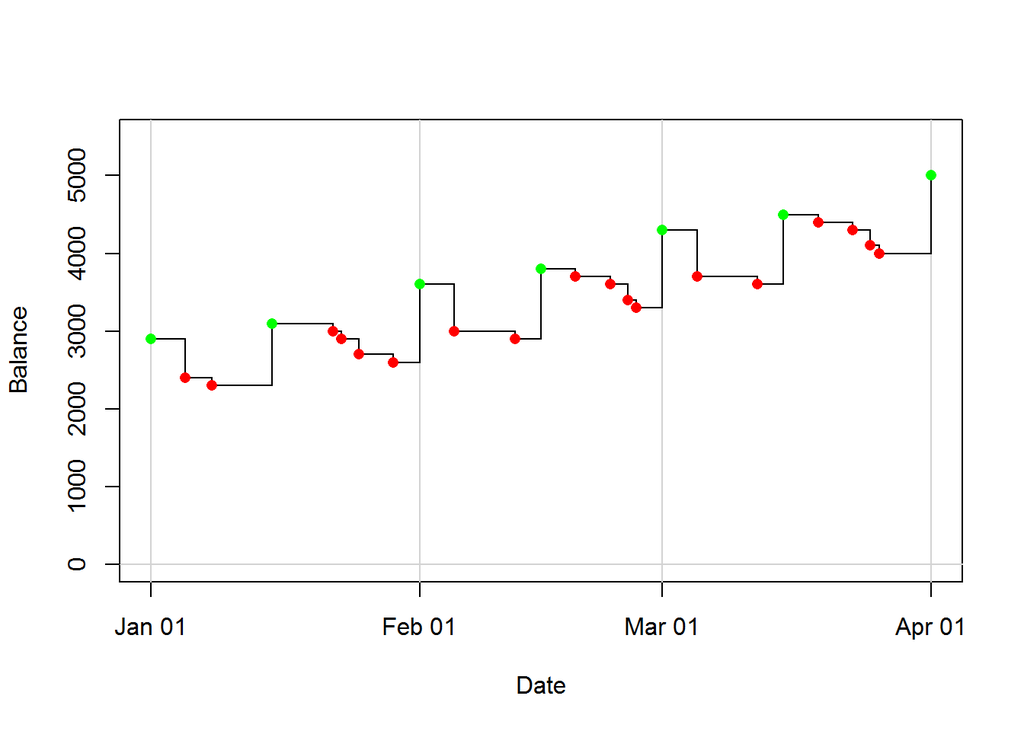

```r
plot(your_budget)
```

#### Reusing in the future

We’ll need to recreate our budget every so often. There are several ways to do so depending on your personal preference, which include but are not limited to:

- Write an R script that you can use to recreate all of your items, schedules, and budgets when needed
- Use base R functions like `save` and `saveRDS` to save a workspace with your items or to save your individual items, schedules, and budgets

#### Updating objects

But what if our rent goes up? It’s easy to update our `rent` item with the `update_item` function. Any arguments not specified (e.g. `name`) will be remain unchanged.

```r
rent <- update_item(rent, amount=-750)
```

We can then recreate our schedule (using the `get_items()` function to include all items in our current environment) and budget to see if anything substantial changed!

```r
your_schedule <- create_schedule(get_items())
your_budget <- create_budget(your_schedule, start="2017-01-01", initial=2000)
your_budget
```

```
## budget (budgetr)
##        date           name amount balance
##  2017-01-01 Initial Amount   2000    2000
##  2017-01-01      Groceries   -100    1900
##  2017-01-01       Paycheck   1000    2900
##  2017-01-05           Rent   -750    2150
##  2017-01-08      Groceries   -100    2050
##  2017-01-15      Groceries   -100    1950
##  2017-01-15       Internet   -100    1850
##  2017-01-15       Paycheck   1000    2850
##  2017-01-22      Groceries   -100    2750
##  2017-01-23   Student Loan   -100    2650
##  2017-01-25            Car   -200    2450
##  2017-01-29      Groceries   -100    2350
##  2017-02-01       Paycheck   1000    3350
##  2017-02-05      Groceries   -100    3250
##  2017-02-05           Rent   -750    2500
##  2017-02-12      Groceries   -100    2400
##  2017-02-15       Internet   -100    2300
##  2017-02-15       Paycheck   1000    3300
##  2017-02-19      Groceries   -100    3200
##  2017-02-23   Student Loan   -100    3100
##  2017-02-25            Car   -200    2900
##  2017-02-26      Groceries   -100    2800
##  2017-03-01       Paycheck   1000    3800
##  2017-03-05      Groceries   -100    3700
##  2017-03-05           Rent   -750    2950
##  2017-03-12      Groceries   -100    2850
##  2017-03-15       Internet   -100    2750
##  2017-03-15       Paycheck   1000    3750
##  2017-03-19      Groceries   -100    3650
##  2017-03-23   Student Loan   -100    3550
##  2017-03-25            Car   -200    3350
##  2017-03-26      Groceries   -100    3250
##  2017-04-01       Paycheck   1000    4250
```

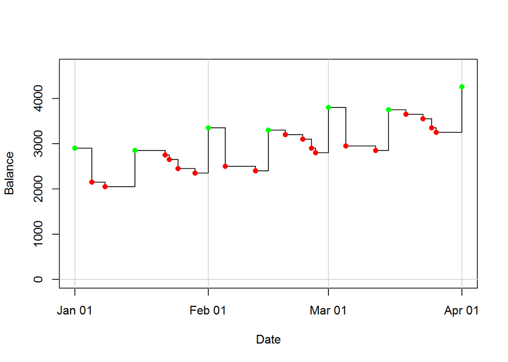

```r
plot(your_budget)
```

There are also functions to quickly update your existing schedules and budgets (e.g. for fast scenario testing):

- `update_schedule` lets you quickly add and/or remove items from a particular schedule. For example, say that you forgot to include the deposit for a late-received Christmas present:

```r
xmas_present <- create_item( name = "Xmas Present"
                           , amount = 200
                           , day = "2017-01-01"
                           )
your_schedule_updated <- update_schedule(your_schedule, add=xmas_present)
```

- `update_budget` lets you quickly change the start date, the end date, and/or the initial amount. For example, say that you wanted to update `your_budget` to apply through the end of 2017:

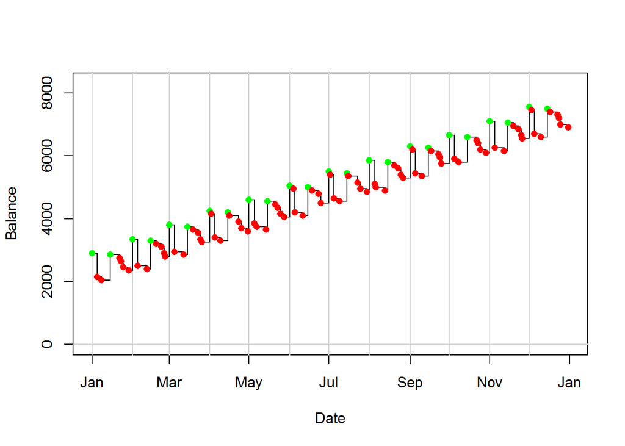

```r
your_budget_2017 <- update_budget(your_budget, end="2017-12-31")
plot(your_budget_2017)
```